# Machine Learning Course Project

# Preliminaries

We first load the packages that we will require, then log the date and time and the scripting environment.

```r
library(caret)                    # machine learning models
library(doParallel)               # parallel processing
```

```r
cl <- makeCluster(detectCores())
registerDoParallel(cl)

library(ggdendro)                 # dendrogram of predictors
#library(rattle)                  # pretty decision tree

library(plyr)                     # loaded here to avoid a conflict below
library(dplyr)                    # for manipulating dataframes
library(reshape2)                 # for manipulating dataframes
```

```r
date()
```

[output not shown]

[output not shown]

# Data Codebook

From the source website:

> Six young health[y] participants were asked to perform one set of 10 repetitions of the Unilateral Dumbbell Biceps Curl in five different fashions: exactly according to the specification (Class A), throwing the elbows to the front (Class B), lifting the dumbbell only halfway (Class C), lowering the dumbbell only halfway (Class D) and throwing the hips to the front (Class E). Class A corresponds to the specified execution of the exercise, while the other 4 classes correspond to common mistakes.

Primary data come from 4 sensors: `arm`, `forearm`, `belt`, `dumbbell`.

38 dimensions are included for each sensor:

- `<axis>_<sensor>`, `<stat>_<axis>_<sensor>`, where
  - `<axis>` is one of {`roll`, `pitch`, `yaw`}
    - NB ‘pitch’ is frequently misspelled as ‘picth’; this is corrected in preprocessing
  - `<stat>` is one of {`kurtosis`, `skewness`, `max`, `min`, `ampltitude`, `avg`, `stddev`, `var`}
- `total_accel_<sensor>`, `var_total_accel_<sensor>`
- `gyros_<sensor>_<dir>`, `accel_<sensor>_<dir>`, and `magnet_<sensor>_<dir>`, where
  - `<dir>` is one of {`x`, `y`, `z`}

Total 152 primary dimensions. The remaining dimensions are:

1. `X`: row index
2. `user_name`: name of the user for that measurement
3. `raw_timestamp_part_1`: some sort of timecode
4. `raw_timestamp_part_2`: some sort of timecode
5. `cvtd_timestamp`: some sort of timecode
6. `new_window`: unknown; values are ‘yes’ and ‘no’
7. `num_window`: unknown; values are integers, ranging from 1 to 864
8. `classe`: performance quality, one of A (correct) or B-E (incorrect, in various common ways)

`X` and `user_name` are kept temporarily for EDA purposes. `classe` is our endpoint. The other dimensions are discarded.

```r
# Drop dimensions that we don't want to use in the analysis
train_data_full <- train_data_full %>% select(-one_of(
    'raw_timestamp_part_1', 'raw_timestamp_part_2',
    'cvtd_timestamp', 'new_window', 'num_window'))
```

# Preprocessing

We first correct the misspellings of ‘pitch’. Note that this is done on the full dataset in order to keep feature names consistent.

```r
# Fix misspellings of 'picth'
names(train_data_full) <- sub('picth', 'pitch', names(train_data_full))
```

We then reserve 30% of the dataset for cross-validation.

```r
# Set a seed for replicability
set.seed(12345)
in_test <- createDataPartition(y = train_data_full$classe, p = 0.3, list=FALSE)
training <- train_data_full %>% slice(-in_test)
testing <- train_data_full %>% slice(in_test)
n <- count(training) %>% as.integer
```

# Exploratory Data Analysis

The data are ordered by `classe`, though not by user. In addition, data from the users are spread over all five values of `classe`.

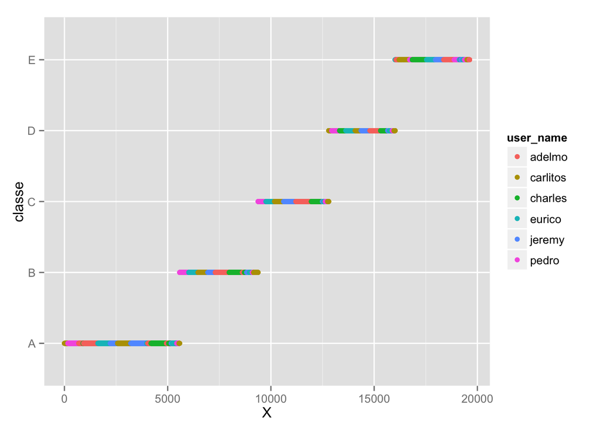

```r
qplot(X, classe, data=training, color=user_name)
```

100 of the primary dimensions are nearly all NAs.

```r
nas <- summarise_each(training, funs(sum(is.na(.))))
na_cols <- nas[,which(nas/n > .90)] %>% names
length(na_cols)
```

```
## [1] 100
```

These NAs do not appear to be correlated with users or `classe`.

```r
# High-NA columns appear to be roughly evenly split across user
group_by(training, user_name) %>% summarize(sum(is.na(max_roll_belt)))
```

```
## Source: local data frame [6 x 2]
##
##   user_name sum(is.na(max_roll_belt))
## 1    adelmo                      2668
## 2  carlitos                      2145
## 3   charles                      2396
## 4    eurico                      2126
## 5    jeremy                      2327
## 6     pedro                      1802
```

```r
# And classe
group_by(training, classe) %>% summarize(sum(is.na(max_roll_belt)))
```

```
## Source: local data frame [5 x 2]
##
##   classe sum(is.na(max_roll_belt))
## 1      A                      3831
## 2      B                      2611
## 3      C                      2343
## 4      D                      2206
## 5      E                      2473
```

So we discard these high-NA dimensions, along with `X` and `user_name`.

```r
# Drop high-NA columns
training <- training %>% select(-one_of(na_cols, 'user_name', 'X'))
```

While this significantly reduces the dimensionality of the dataset, we still have 52 dimensions (plus the endpoint `classe`).

```r
dim(training)
```

```
## [1] 13733    53
```

To consider whether further dimension reduction might be appropriate, we next construct a correlation heat map. Since we are interested in the magnitude of the correlation, we map its absolute value.

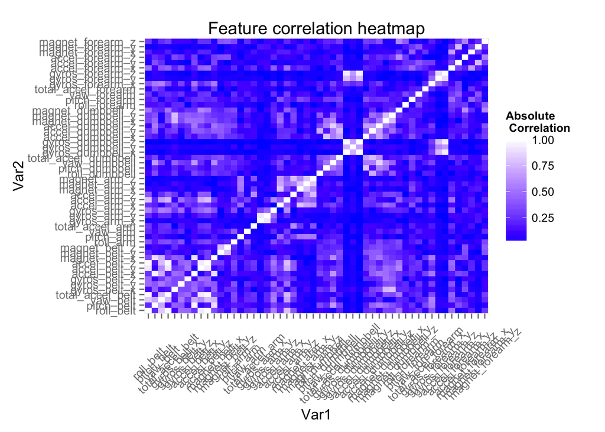

```r
# Following http://www.sthda.com/english/wiki/ggplot2-quick-correlation-matrix-heatmap-r-software-and-data-visualization
# Select everything except classe, calculate correlations,
# Take the absolute value
feature_corr <- select(training, -classe) %>% cor %>% abs
# Use melt to get the proper format for ggplot
feature_heatmap <- feature_corr %>% melt
ggplot(data = feature_heatmap, aes(x=Var1, y=Var2, fill=value)) +
    geom_tile() +
    theme(axis.text.x = element_text(angle = 45, vjust=.5)) +
    scale_fill_gradient(low='blue', high='white', name='Absolute\n Correlation') +
    ggtitle('Feature correlation heatmap')
```

The heatmap indicates some correlations among dimensions. For example, for a given `<sensor>`, the `magnet_<sensor>_<dir>` dimensions are correlated with each other, as are many of the `belt` dimensions. Likewise, a cluster analysis suggests that some dimension reduction is possible.

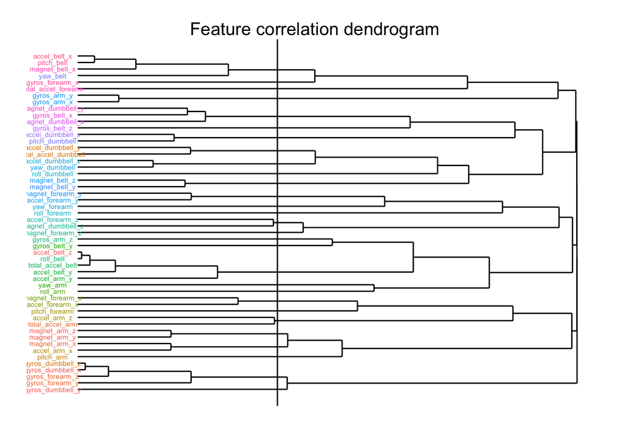

```r
# Similar to the heatmap, only here we want 1-abs(correlation)
# Pass through as.dist so that hclust knows how to interpret it
feature_dist <- 1-feature_corr
feature_tree <- feature_dist %>% as.dist %>% hclust
# cutree needs the hclust version of the tree
threshold <- .4
feature_tree_groups <- cutree(feature_tree, h=threshold)
# While ggplot needs the dendro_data version
feature_tree <- feature_tree %>% as.dendrogram %>% dendro_data
# Plot with ggplot
ggplot(segment(feature_tree)) +
    geom_segment(aes(x=x, y=y, xend=xend, yend=yend)) +
    geom_text(data=label(feature_tree), size=2,
              aes(label=label, x=x, y=-.05,
                color=as.factor(feature_tree_groups))) +
    geom_hline(y=threshold, color='black') +
    scale_color_discrete(guide=FALSE) +
    ggtitle('Feature correlation dendrogram') +
    coord_flip() +
    theme_dendro()
```

In an earlier version of this analysis, PCA was used to achieve further dimension reduction. `prcomp` indicated that over 95% of the variance in the predictors could be captured by the first 9 principal components, which would be a significant reduction. However, for reasons I don’t understand, `caret` kept 32 principal components, for a modest reduction of dimension and a significant increase in computation time. (And, in the case of the decision tree model, a significant decrease in model quality.) Thus, no further dimension reduction is used here.

# Model Construction and Evaluation

For each modelling algorithm, we use 5-fold cross-validation, then test the resulting model against the reserved data.

```r
trcontrol <- trainControl(method='cv', number=5)
```

## $k$-nearest neighbor model

Pre-processing is used to center and scale the data for this model.

```r
# Set a seed to break ties
set.seed(12345)
# Start a timer
knn_t0 <- proc.time()
# Train the model
knn_model <- train(classe ~ ., data = training, method = 'knn',
                   trControl = trcontrol,
                   preProcess = c('center', 'scale'))
# Stop the timer
knn_t1 <- proc.time()
knn_t <- knn_t1 - knn_t0
```

```r
# Model diagnostics and execution time
knn_model
```

```
## k-Nearest Neighbors
##
## 13733 samples
##    52 predictor
##     5 classes: 'A', 'B', 'C', 'D', 'E'
##
## Pre-processing: centered, scaled
## Resampling: Cross-Validated (5 fold)
##
## Summary of sample sizes: 10987, 10986, 10986, 10986, 10987
##
## Resampling results across tuning parameters:
##
##   k  Accuracy   Kappa      Accuracy SD  Kappa SD
##   5  0.9552905  0.9434356  0.004863422  0.006150738
##   7  0.9397076  0.9237079  0.003919935  0.004954125
##   9  0.9278381  0.9086789  0.005377268  0.006783493
##
## Accuracy was used to select the optimal model using  the largest value.
## The final value used for the model was k = 5.
```

```r
knn_t
```

```
##    user  system elapsed
##   1.031   0.062  37.359
```

```r
# Generate predictions on the reserved test set
knn_pred <- predict(knn_model, testing)
confusionMatrix(knn_pred, testing$classe)
```

```
## Confusion Matrix and Statistics
##
##           Reference
## Prediction    A    B    C    D    E
##          A 1654   46    2    1    0
##          B    6 1062   14    0    4
##          C    5   26  990   32    9
##          D    6    4   17  930   14
##          E    3    2    4    2 1056
##
## Overall Statistics
##
##                Accuracy : 0.9665
##                  95% CI : (0.9616, 0.971)
##     No Information Rate : 0.2843
##     P-Value [Acc > NIR] : < 2.2e-16
##
##                   Kappa : 0.9577
##  Mcnemar's Test P-Value : 1.266e-09
##
## Statistics by Class:
##
##                      Class: A Class: B Class: C Class: D Class: E
## Sensitivity            0.9881   0.9316   0.9640   0.9637   0.9751
## Specificity            0.9884   0.9949   0.9852   0.9917   0.9977
## Pos Pred Value         0.9712   0.9779   0.9322   0.9578   0.9897
## Neg Pred Value         0.9952   0.9838   0.9923   0.9929   0.9944
## Prevalence             0.2843   0.1936   0.1744   0.1639   0.1839
## Detection Rate         0.2809   0.1803   0.1681   0.1579   0.1793
## Detection Prevalence   0.2892   0.1844   0.1803   0.1649   0.1812
## Balanced Accuracy      0.9882   0.9633   0.9746   0.9777   0.9864
```

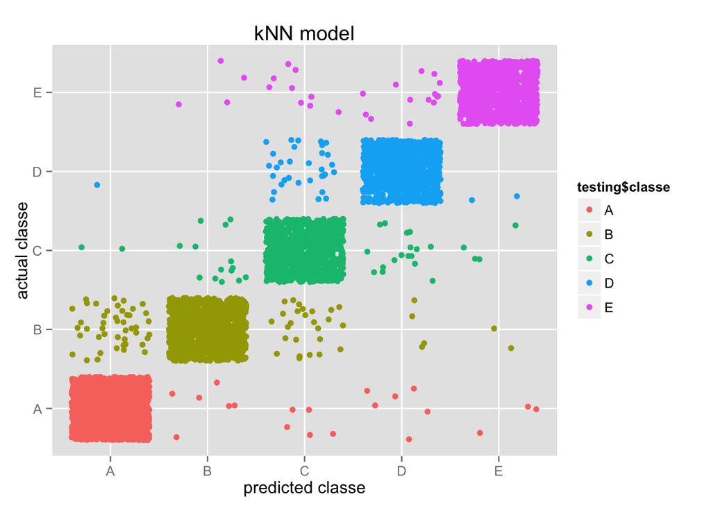

```r
qplot(knn_pred, testing$classe,
      position = 'jitter', color=testing$classe, xlab = 'predicted classe',
      ylab = 'actual classe', main='kNN model')
```

## Decision tree model

```r
# The steps here work the same as those above, unless noted
tree_t0 <- proc.time()
tree_model <- train(classe ~ ., data=training, method='rpart',
                    trControl = trcontrol)
tree_t1 <- proc.time()
tree_t <- tree_t1 - tree_t0
```

```r
tree_t
```

```
##    user  system elapsed
##   5.389   0.062   8.391
```

```r
tree_model
```

```
## CART
##
## 13733 samples
##    52 predictor
##     5 classes: 'A', 'B', 'C', 'D', 'E'
##
## No pre-processing
## Resampling: Cross-Validated (5 fold)
##
## Summary of sample sizes: 10986, 10986, 10986, 10988, 10986
##
## Resampling results across tuning parameters:
##
##   cp          Accuracy   Kappa       Accuracy SD  Kappa SD
##   0.03419151  0.5126315  0.36241276  0.015024280  0.020224388
##   0.06017435  0.3661252  0.12446623  0.002576485  0.003995996
##   0.11417523  0.3324885  0.07324304  0.044000222  0.066889295
##
## Accuracy was used to select the optimal model using  the largest value.
## The final value used for the model was cp = 0.03419151.
```

```r
# Generate a pretty plot using `rattle`
#fancyRpartPlot(tree_model$finalModel)
tree_pred <- predict(tree_model,testing)
confusionMatrix(tree_pred,testing$classe)
```

```
## Confusion Matrix and Statistics
##
##           Reference
## Prediction    A    B    C    D    E
##          A 1507  483  465  436  172
##          B   25  382   26  176  141
##          C  141  275  536  353  274
##          D    0    0    0    0    0
##          E    1    0    0    0  496
##
## Overall Statistics
##
##                Accuracy : 0.496
##                  95% CI : (0.4832, 0.5089)
##     No Information Rate : 0.2843
##     P-Value [Acc > NIR] : < 2.2e-16
##
##                   Kappa : 0.3414
##  Mcnemar's Test P-Value : NA
##
## Statistics by Class:
##
##                      Class: A Class: B Class: C Class: D Class: E
## Sensitivity            0.9002  0.33509  0.52191   0.0000  0.45799
## Specificity            0.6308  0.92251  0.78548   1.0000  0.99979
## Pos Pred Value         0.4920  0.50933  0.33946      NaN  0.99799
## Neg Pred Value         0.9409  0.85250  0.88608   0.8361  0.89114
## Prevalence             0.2843  0.19358  0.17439   0.1639  0.18390
## Detection Rate         0.2559  0.06487  0.09102   0.0000  0.08422
## Detection Prevalence   0.5201  0.12736  0.26813   0.0000  0.08439
## Balanced Accuracy      0.7655  0.62880  0.65369   0.5000  0.72889
```

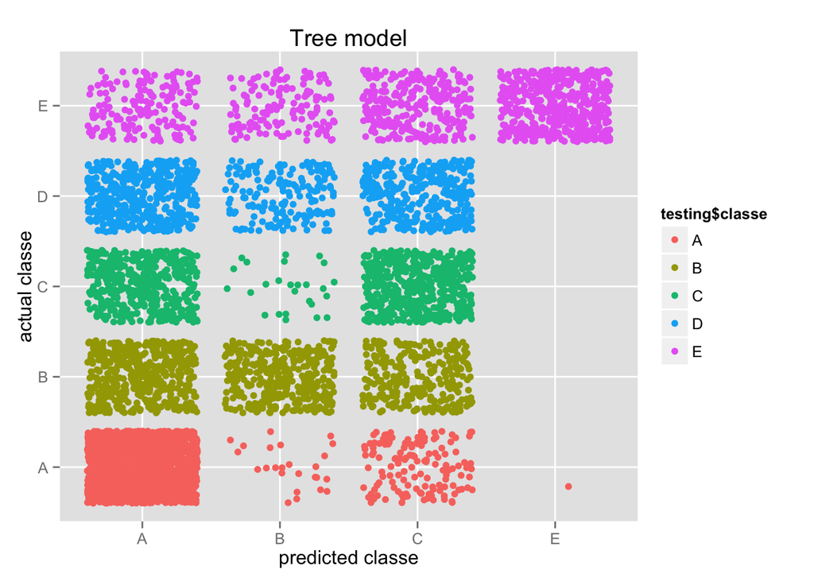

```r
qplot(tree_pred, testing$classe,
      position = 'jitter', color=testing$classe, xlab = 'predicted classe',
      ylab = 'actual classe', main='Tree model')
```

This model is very fast to train (about 10 seconds on my laptop), but has very low accuracy and overall is only somewhat better than chance. Note that it misclassifies every D.

## Bag model

```r
# The steps here work the same as those above, unless noted
bag_t0 <- proc.time()
bag_model <- train(classe ~., data=training, method='treebag',
                   trControl = trcontrol)
bag_t1 <- proc.time()
bag_t <- bag_t1 - bag_t0
```

```r
bag_model
```

```
## Bagged CART
##
## 13733 samples
##    52 predictor
##     5 classes: 'A', 'B', 'C', 'D', 'E'
##
## No pre-processing
## Resampling: Cross-Validated (5 fold)
##
## Summary of sample sizes: 10988, 10986, 10987, 10986, 10985
##
## Resampling results
##
##   Accuracy   Kappa      Accuracy SD  Kappa SD
##   0.9839802  0.9797346  0.002288489  0.00289689
##
##
```

```r
bag_t
```

```
##    user  system elapsed
##  40.551   0.326 118.087
```

```r
bag_pred <- predict(bag_model, testing)
confusionMatrix(bag_pred, testing$classe)
```

```
## Confusion Matrix and Statistics
##
##           Reference
## Prediction    A    B    C    D    E
##          A 1664   17    0    0    1
##          B    5 1107   15    5    6
##          C    3   11 1005   13    5
##          D    0    4    7  946    8
##          E    2    1    0    1 1063
##
## Overall Statistics
##
##                Accuracy : 0.9823
##                  95% CI : (0.9786, 0.9855)
##     No Information Rate : 0.2843
##     P-Value [Acc > NIR] : < 2.2e-16
##
##                   Kappa : 0.9777
##  Mcnemar's Test P-Value : NA
##
## Statistics by Class:
##
##                      Class: A Class: B Class: C Class: D Class: E
## Sensitivity            0.9940   0.9711   0.9786   0.9803   0.9815
## Specificity            0.9957   0.9935   0.9934   0.9961   0.9992
## Pos Pred Value         0.9893   0.9728   0.9691   0.9803   0.9963
## Neg Pred Value         0.9976   0.9931   0.9955   0.9961   0.9959
## Prevalence             0.2843   0.1936   0.1744   0.1639   0.1839
## Detection Rate         0.2826   0.1880   0.1707   0.1606   0.1805
## Detection Prevalence   0.2856   0.1932   0.1761   0.1639   0.1812
## Balanced Accuracy      0.9949   0.9823   0.9860   0.9882   0.9904
```

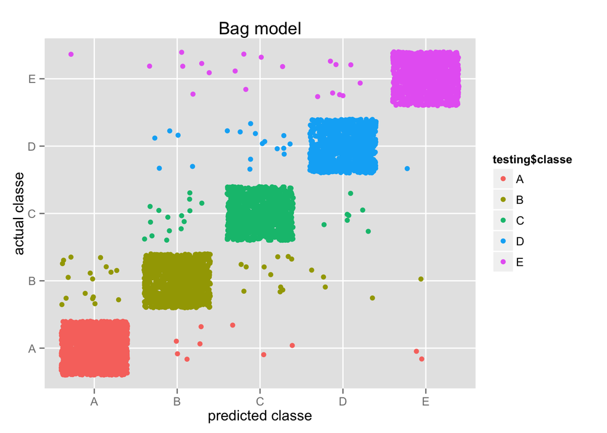

```r
qplot(bag_pred, testing$classe,
      position = 'jitter', color=testing$classe, xlab = 'predicted classe',
      ylab = 'actual classe', main='Bag model')
```

`caret` provides `varImp`, which extracts information about the most important variables, scaled from 0 to 100.

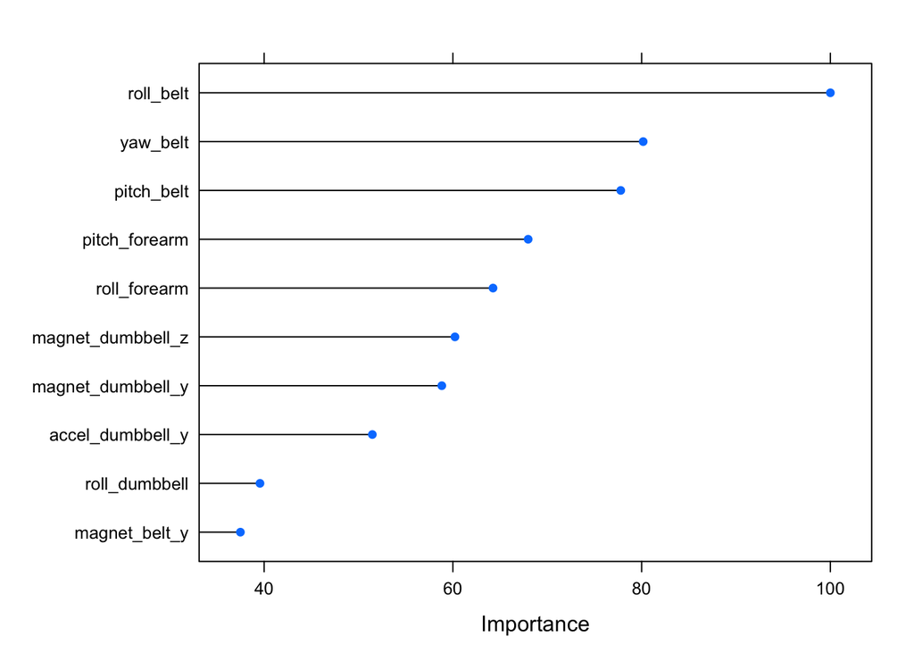

```r
varImp(bag_model) %>% plot(., top=10)
```

The most important variables in the bag model appear to be `roll_belt`, `yaw_belt`, `pitch_belt`, `pitch_forearm`, `roll_forearm`, `magnet_dumbbell_z`, and `magnet_dumbbell_y`.

## Random forest model

```r
rf_t0 <- proc.time()
rf_model <- train(classe ~ ., data = training, method = 'rf',
                   trControl = trcontrol)
rf_t1 <- proc.time()
rf_t <- rf_t1 - rf_t0
```

```r
rf_model
```

```
## Random Forest
##
## 13733 samples
##    52 predictor
##     5 classes: 'A', 'B', 'C', 'D', 'E'
##
## No pre-processing
## Resampling: Cross-Validated (5 fold)
##
## Summary of sample sizes: 10985, 10986, 10987, 10987, 10987
##
## Resampling results across tuning parameters:
##
##   mtry  Accuracy   Kappa      Accuracy SD  Kappa SD
##    2    0.9910432  0.9886693  0.001051315  0.001329772
##   27    0.9916264  0.9894078  0.001941646  0.002456119
##   52    0.9849271  0.9809325  0.002848884  0.003603307
##
## Accuracy was used to select the optimal model using  the largest value.
## The final value used for the model was mtry = 27.
```

```r
rf_t
```

```
##    user  system elapsed
##  45.457   0.645 259.699
```

```r
rf_pred <- predict(rf_model, testing)
confusionMatrix(rf_pred, testing$classe)
```

```
## Confusion Matrix and Statistics
##
##           Reference
## Prediction    A    B    C    D    E
##          A 1673   12    0    0    0
##          B    0 1123    5    2    1
##          C    1    4 1019   11    2
##          D    0    1    3  951    4
##          E    0    0    0    1 1076
##
## Overall Statistics
##
##                Accuracy : 0.992
##                  95% CI : (0.9894, 0.9941)
##     No Information Rate : 0.2843
##     P-Value [Acc > NIR] : < 2.2e-16
##
##                   Kappa : 0.9899
##  Mcnemar's Test P-Value : NA
##
## Statistics by Class:
##
##                      Class: A Class: B Class: C Class: D Class: E
## Sensitivity            0.9994   0.9851   0.9922   0.9855   0.9935
## Specificity            0.9972   0.9983   0.9963   0.9984   0.9998
## Pos Pred Value         0.9929   0.9929   0.9826   0.9917   0.9991
## Neg Pred Value         0.9998   0.9964   0.9984   0.9972   0.9985
## Prevalence             0.2843   0.1936   0.1744   0.1639   0.1839
## Detection Rate         0.2841   0.1907   0.1730   0.1615   0.1827
## Detection Prevalence   0.2861   0.1921   0.1761   0.1628   0.1829
## Balanced Accuracy      0.9983   0.9917   0.9943   0.9919   0.9967
```

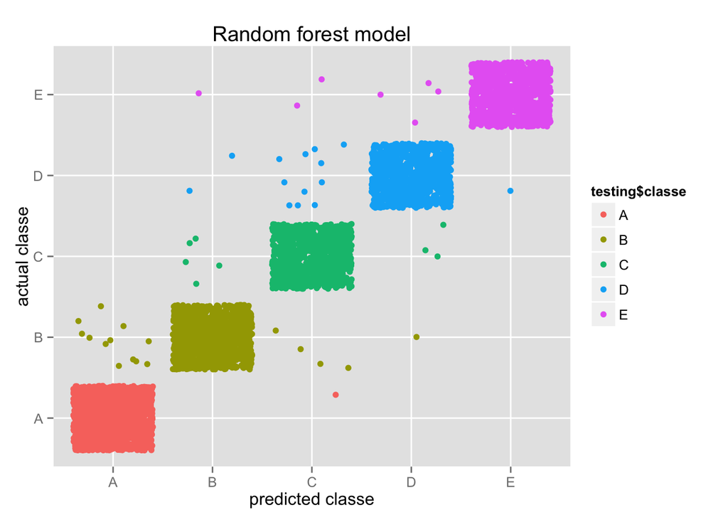

```r
qplot(rf_pred, testing$classe,
      position = 'jitter', color=testing$classe, xlab = 'predicted classe',
      ylab = 'actual classe', main = 'Random forest model')
```

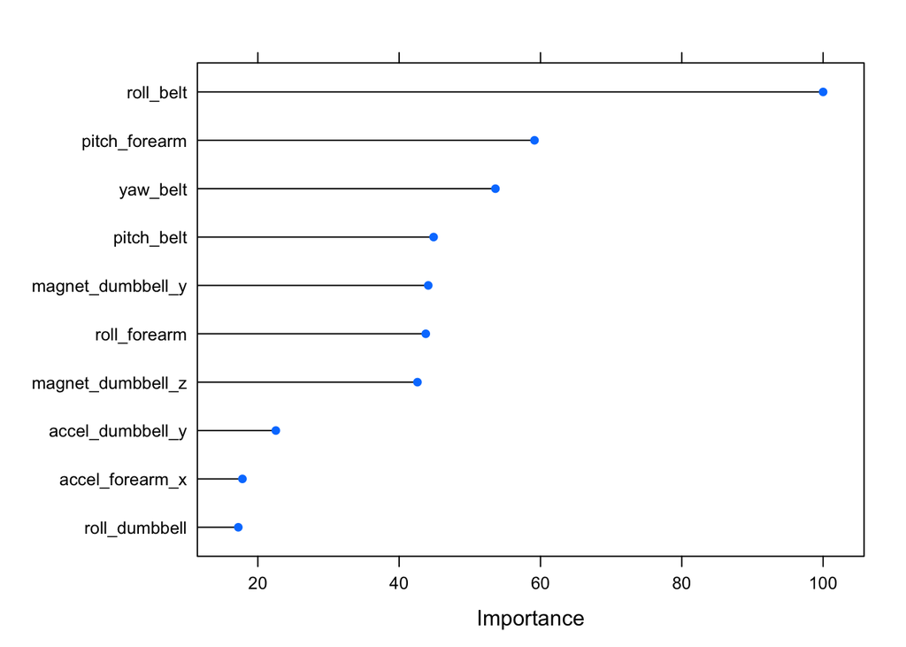

```r
varImp(rf_model) %>% plot(., top=10)
```

The most important variables in the random forest model appear to be `roll_belt`, `pitch_forearm`, `yaw_belt`, `pitch_belt`, `magnet_dumbbell_y`, `roll_forearm`, and `magnet_dumbbell_z`. Note that these are the same variables used in the bag model.

# Summary

Both bagging and random forests are extremely accurate, with estimated 98% and 99% out-of-sample accuracy rates, respectively. However, they are relatively computationally intensive. In situations where scalability is more important and a small sacrifice in accuracy is acceptable, the $k$-nearest-neighbor model may be preferable. This model has an estimated 96% out-of-sample accuracy rate.

# Test data

The testing data are downloaded and ‘picth’ is corrected as with the training data. After work began on htis section, only typos were corrected in the preceding sections.

```r
# Download dataset
testing_file <- 'test.csv'
if (!file.exists(testing_file)) {
    download.file(
        'https://d396qusza40orc.cloudfront.net/predmachlearn/pml-testing.csv',
        testing_file,
        'curl')
}
# Read the csv
test_data_full <- read.csv(testing_file,
                            na.strings = c('#DIV/0!', 'NA'))
# Fix misspellings of 'picth'
names(test_data_full) <- sub('picth', 'pitch', names(test_data_full))
```

We use the random forest model.

```r
test_pred <- predict(rf_model, test_data_full)
```

To generate the files for submission, we follow the approach suggested in the instructions.

```r
# Define the function to generate the submission files
pml_write_files = function(x){
  n = length(x)
  for(i in 1:n){
    filename = paste0("problem_id_",i,".txt")
    write.table(x[i],file=filename,quote=FALSE,row.names=FALSE,col.names=FALSE)
  }
}

# Move to a subfolder
original_wd <- getwd()
predictions_folder <- paste(original_wd, '/predictions/', sep='')
if (!file.exists(predictions_folder)) {
    dir.create(predictions_folder)
}
setwd(predictions_folder)

# Write the files
pml_write_files(test_pred)

# Move back up to the original working directory
setwd(original_wd)
```